# Land Use Feature Selection, Random Forest Optimization, Classification and Validation

### The following code in this document describes the actions that were taken in order to process, optimize, train, predict and validate the Land Use classification for the city of Ouagadougou. The same approach was applied for the Dakar.

### The code assumes the training and testing data have already been prepared.

### Import relevant libraries for the task at hand

```r
library(randomForest)
library(xgboost)
library(caret)
library(VSURF)
library(foreign)
library(rgdal)
```

### Load training and validation blocks. Column name “label” refers to the class of the block while information from column 8 and onwards are the independant variables

```r
library(readr)
train <- read_csv("Datasets/Finaldataset/train.csv")
test <- read_csv("Datasets/Finaldataset/test.csv")
alldata <- read_csv("Datasets/Finaldataset/alldata.csv")
head(summary(train))
```

```
##        X1              X1_1           gid            label
##  Min.   :   1.0   Min.   :   1   Min.   :   67   Min.   :0.000
##  1st Qu.: 263.0   1st Qu.: 353   1st Qu.:11738   1st Qu.:1.000
##  Median : 525.0   Median : 702   Median :24912   Median :2.000
##  Mean   : 528.7   Mean   : 708   Mean   :24037   Mean   :1.907
##  3rd Qu.: 796.0   3rd Qu.:1068   3rd Qu.:36073   3rd Qu.:3.000
##  Max.   :1067.0   Max.   :1422   Max.   :47351   Max.   :4.000
##   uncertain          heterogen              cat
##  Length:1085        Length:1085        Min.   :    3
##  Class :character   Class :character   1st Qu.: 7723
##  Mode  :character   Mode  :character   Median :16814
##                                        Mean   :16123
##                                        3rd Qu.:23659
##                                        Max.   :31921
##  map_6_shadowback_dominance map_6_shadowback_pielou map_6_shadowback_renyi
##  Min.   :0.002733           Min.   :0.04686         Min.   :0.01038
##  1st Qu.:0.424660           1st Qu.:0.49852         1st Qu.:0.57338
##  Median :0.636039           Median :0.64204         Median :0.93632
##  Mean   :0.657629           Mean   :0.62165         Mean   :0.92522
##  3rd Qu.:0.852154           3rd Qu.:0.76976         3rd Qu.:1.27718
##  Max.   :1.803260           Max.   :0.99606         Max.   :1.84175
##  map_6_shadowback_richness map_6_shadowback_shannon
##  Min.   :2.000             Min.   :0.03248
##  1st Qu.:5.000             1st Qu.:0.81539
##  Median :6.000             Median :1.17121
##  Mean   :6.155             Mean   :1.13365
##  3rd Qu.:7.000             3rd Qu.:1.47820
##  Max.   :9.000             Max.   :1.91682
##  map_6_shadowback_simpson map_6_shadowback_cl_13_patchnum
##  Min.   :0.01033          Min.   : 0.0000
##  1st Qu.:0.43638          1st Qu.: 0.0000
##  Median :0.60793          Median : 0.0000
##  Mean   :0.56369          Mean   : 0.6765
##  3rd Qu.:0.72118          3rd Qu.: 1.0000
##  Max.   :0.84146          Max.   :27.0000
##  map_6_shadowback_cl_13_patchdensity map_6_shadowback_cl_13_mps
##  Min.   :0.0000                      Min.   :0.0000000
##  1st Qu.:0.0000                      1st Qu.:0.0000000
##  Median :0.0000                      Median :0.0000000
##  Mean   :0.1058                      Mean   :0.0002897
```

[output cut: 232 more lines]

```
##  Max.   : 0.1336   Max.   :42.610    Max.   :291963    Max.   :3.95520
##     prop_14          prop_20         prop_30         prop_31
##  Min.   : 0.000   Min.   : 0.00   Min.   : 0.00   Min.   : 0.000
##  1st Qu.: 0.000   1st Qu.:11.76   1st Qu.:13.59   1st Qu.: 1.322
##  Median : 0.000   Median :27.67   Median :34.70   Median : 3.078
##  Mean   : 3.356   Mean   :29.83   Mean   :40.16   Mean   : 5.985
##  3rd Qu.: 0.000   3rd Qu.:43.40   3rd Qu.:65.89   3rd Qu.: 7.139
##  Max.   :97.588   Max.   :96.62   Max.   :99.48   Max.   :86.056
##     prop_41           prop_51          prop_111          prop_112
##  Min.   : 0.0000   Min.   : 0.000   Min.   : 0.0000   Min.   : 0.0000
##  1st Qu.: 0.0000   1st Qu.: 2.301   1st Qu.: 0.0000   1st Qu.: 0.8898
##  Median : 0.0000   Median : 5.050   Median : 0.6859   Median : 4.5675
##  Mean   : 0.4531   Mean   : 5.859   Mean   : 6.1271   Mean   : 8.0633
##  3rd Qu.: 0.0000   3rd Qu.: 8.949   3rd Qu.: 9.4200   3rd Qu.:11.7057
##  Max.   :89.9898   Max.   :24.479   Max.   :57.3602   Max.   :58.2663
```

### Perform Feature Selection based on the VSURF algorithm (Genuer et al. 2015). The output is a feature subset with the least amount of possible features, devoid of redundancy while mainting similar if not better predictive capabilities.

```r
library(VSURF)
surf=VSURF(as.factor(train$label) ~ ., norm.votes=FALSE, data=train[,8:96],ncores=16,parallel=TRUE)
index=colnames(train[surf$varselect.pred+7])
print(index)
```

```
##  [1] "mean_build_height"
##  [2] "prop_111"
##  [3] "map_6_shadowback_cl_112_patchdensity"
##  [4] "prop_112"
##  [5] "map_6_shadowback_cl_111_mps"
##  [6] "map_6_shadowback_cl_30_patchdensity"
##  [7] "ndvi_median"
##  [8] "map_6_shadowback_cl_51_patchdensity"
##  [9] "map_6_shadowback_cl_111_padsd"
## [10] "map_6_shadowback_cl_31_mps"
## [11] "map_6_shadowback_cl_112_patchnum"
## [12] "map_6_shadowback_cl_51_shape"
## [13] "map_6_shadowback_cl_20_patchdensity"
## [14] "map_6_shadowback_cl_112_padsd"
## [15] "map_6_shadowback_cl_51_patchnum"
## [16] "map_6_shadowback_shannon"
## [17] "map_6_shadowback_cl_14_padsd"
## [18] "compact_circle"
```

### Fine tuning the “mtry” parameter of the RF using crossvalidation of the Out of Bag (OOB) error.

```r
set.seed(2)
res <- tuneRF(x = train[,index],y = as.factor(train$label),ntreeTry = 2000)
```

```
## mtry = 4  OOB error = 17.33%
## Searching left ...
## mtry = 2     OOB error = 17.51%
## -0.0106383 0.05
## Searching right ...
## mtry = 8     OOB error = 17.7%
## -0.0212766 0.05
```

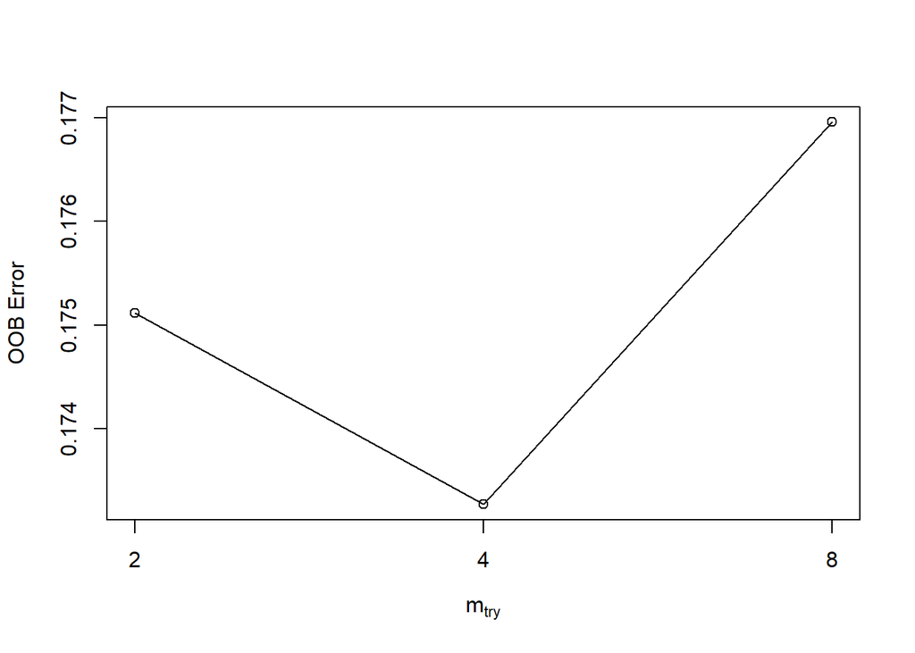

```r
mtry_opt <- res[,"mtry"][which.min(res[,"OOBError"])]
```

### Train the feature optimized and parameter fine-tuned RF model. In the end the Overall Accuracy (OA) based on the test set is computed along with several other class metrics

```r
library(e1071)
set.seed(11)
rf_train=randomForest(as.factor(train$label) ~ ., data=train[,index],ntree=2000,mtry=4,importance=TRUE)
pred=predict(rf_train, as.matrix(test[,index]))
rftable=table(pred,as.factor(test$label))
rf_CM=confusionMatrix(rftable)
print(rf_CM)
```

```
## Confusion Matrix and Statistics
##
##
## pred  0  1  2  3  4
##    0 47  0  9  0  0
##    1  4 48  0  1  3
##    2 15  2 77  2  0
##    3  2  1  4 78  2
##    4  0  6  0  2 36
##
## Overall Statistics
##
##                Accuracy : 0.8437
##                  95% CI : (0.8005, 0.8806)
##     No Information Rate : 0.2655
##     P-Value [Acc > NIR] : < 2.2e-16
##
##                   Kappa : 0.8009
##  Mcnemar's Test P-Value : NA
##
## Statistics by Class:
##
##                      Class: 0 Class: 1 Class: 2 Class: 3 Class: 4
## Sensitivity            0.6912   0.8421   0.8556   0.9398   0.8780
## Specificity            0.9668   0.9716   0.9237   0.9648   0.9732
## Pos Pred Value         0.8393   0.8571   0.8021   0.8966   0.8182
## Neg Pred Value         0.9258   0.9682   0.9465   0.9802   0.9831
## Prevalence             0.2006   0.1681   0.2655   0.2448   0.1209
## Detection Rate         0.1386   0.1416   0.2271   0.2301   0.1062
## Detection Prevalence   0.1652   0.1652   0.2832   0.2566   0.1298
## Balanced Accuracy      0.8290   0.9069   0.8896   0.9523   0.9256
```

### Predict in the whole dataset of Ouagadougou and save the results in a csv. Both class probabilities and the final label are computed.

```r
pred_all=predict(rf_train, as.matrix(alldata[,index]))
rf_pred_final=cbind(pred_all,alldata[1],alldata[2])
write.csv(rf_pred_final, file = "Predictions_VSURF.csv")
pred_all=predict(rf_train, as.matrix(alldata[,index]),type="prob")
rf_pred_final=cbind(pred_all,alldata[1],alldata[2])
write.csv(rf_pred_final, file = "Predictions_VSURF_SOFTPROB.csv")
```

### Save feature importances

```r
f_importnace= rf_train$importance
write.csv(f_importnace, file="Feature_importance_Final.csv")
```